# FCA algorithms with the R package fcaR

Working and learning together with fcaR

# 1 Background in FCA

We show some of the main methods of FCA using the functionalities and data structures of the `fcaR` package.

Following the discourse of:

> Conceptual Exploration - B. Ganter, S. Obiedkov - 2016.

> > “about attribute exploration” + “knowledge acquisition technique”

# 2 Structure of `fcaR`

The `fcaR` package provides data structures which allow the user to work seamlessly with formal contexts and sets of implications. Three basic objects wil be used in R language:

- `FormalContext` encapsulates the definition of a formal context $(G, M, I)$, being $G$ the set of objects, $M$ the set of attributes and $I$ the (fuzzy) relationship matrix, and provides methods to operate on the context using FCA tools.
- `ImplicationSet` represents a set of implications over a specific formal context.
- `Set` encapsulates a class for storing variables (attributes or objects) in an efficient way.

As an advantage, object oriented programming style of R language and all the knowledge (concepts, implications, minimal generators, etc.) will be stored inside the *formal context object*.

`fcaR` includes documentation and vignettes.

- From the point of view of efficiency, the `fcaR` package uses the vectorial and parallelization capabilities of the R language, whereas algorithmic bottlenecks have been implemented in C.
- Currently, the package is under active development.
- As of today the package has 22000 downloads, published in CRAN repositories (https://cran.rstudio.com/web/packages/fcaR/index.html) with a living live cycle https://github.com/Malaga-FCA-group/fcaR and with vignettes to spread the package https://neuroimaginador.github.io/fcaR/.

# 3 Using `fcaR`

## 3.1 Formal contexts

The first step when using the `fcaR` package to analyse a formal context is to create a variable of class `FormalContext` which will store all the information related to the context.

Internally, the object stores information about whether the context is binary or the names of objects and attributes, which are taken from the rownames and colnames of the provided matrix, etc.

We use the Formal Context, $\mathbf{ K} := (G, M, I)$ about planets:

> Wille R (1982). “Restructuring Lattice Theory: An Approach Based on Hierarchies of Concepts.” In Ordered Sets, pp. 445–470. Springer.

**🪄Exercise:** :

- Loading the `fcaR` package
- Importing the dataset planets
- Visualizing the dataset

```r
library(fcaR)
data("planets")
```

- Visualizing the dataset

```r
knitr::kable(planets, format = "html", booktabs = TRUE)
```

|  | small | medium | large | near | far | moon | no_moon |
| --- | --- | --- | --- | --- | --- | --- | --- |
| Mercury | 1 | 0 | 0 | 1 | 0 | 0 | 1 |
| Venus | 1 | 0 | 0 | 1 | 0 | 0 | 1 |
| Earth | 1 | 0 | 0 | 1 | 0 | 1 | 0 |
| Mars | 1 | 0 | 0 | 1 | 0 | 1 | 0 |
| Jupiter | 0 | 0 | 1 | 0 | 1 | 1 | 0 |
| Saturn | 0 | 0 | 1 | 0 | 1 | 1 | 0 |
| Uranus | 0 | 1 | 0 | 0 | 1 | 1 | 0 |
| Neptune | 0 | 1 | 0 | 0 | 1 | 1 | 0 |
| Pluto | 1 | 0 | 0 | 0 | 1 | 1 | 0 |

- Creating a variable `fc_planets`

```r
fc_planets <- FormalContext$new(planets)
fc_planets
```

```
## FormalContext with 9 objects and 7 attributes.
##          small  medium  large  near  far  moon  no_moon
##  Mercury   X                     X                 X
##    Venus   X                     X                 X
##    Earth   X                     X          X
##     Mars   X                     X          X
##  Jupiter                  X           X     X
##   Saturn                  X           X     X
##   Uranus           X                  X     X
##  Neptune           X                  X     X
##    Pluto   X                          X     X
```

> > `fc_planets` is a R variable which stores the formal context $\mathbf{ K}$ but also, all the knowledge related with the data inside:
- the attributes $M$,
- the objects $G$,
- the incidence relation
- the concepts (when they will be computed)
- the implications (when they will be computed)
- etc.

> > **Help**: fcaR for your .tex documents:

```r
fc_planets$to_latex(caption = "Planets dataset.", label = "tab:planets")
```

```
## \begin{table} \centering \begin{tabular}{lccccccc}
## \toprule
##  & small & medium & large & near & far & moon & no\_moon\\
## \midrule
## Mercury & $\times$ &   &   & $\times$ &   &   & $\times$\\
## Venus & $\times$ &   &   & $\times$ &   &   & $\times$\\
## Earth & $\times$ &   &   & $\times$ &   & $\times$ &  \\
## Mars & $\times$ &   &   & $\times$ &   & $\times$ &  \\
## Jupiter &   &   & $\times$ &   & $\times$ & $\times$ &  \\
## Saturn &   &   & $\times$ &   & $\times$ & $\times$ &  \\
## Uranus &   & $\times$ &   &   & $\times$ & $\times$ &  \\
## Neptune &   & $\times$ &   &   & $\times$ & $\times$ &  \\
## Pluto & $\times$ &   &   &   & $\times$ & $\times$ &  \\
## \bottomrule
## \end{tabular} \caption{\label{tab:planets}Planets dataset.} \end{table}
```

> `fc_planets` can be printed or plotted (in gray scale for fuzzy datasets)

```r
fc_planets$print()
```

```
## FormalContext with 9 objects and 7 attributes.
##          small  medium  large  near  far  moon  no_moon
##  Mercury   X                     X                 X
##    Venus   X                     X                 X
##    Earth   X                     X          X
##     Mars   X                     X          X
##  Jupiter                  X           X     X
##   Saturn                  X           X     X
##   Uranus           X                  X     X
##  Neptune           X                  X     X
##    Pluto   X                          X     X
```

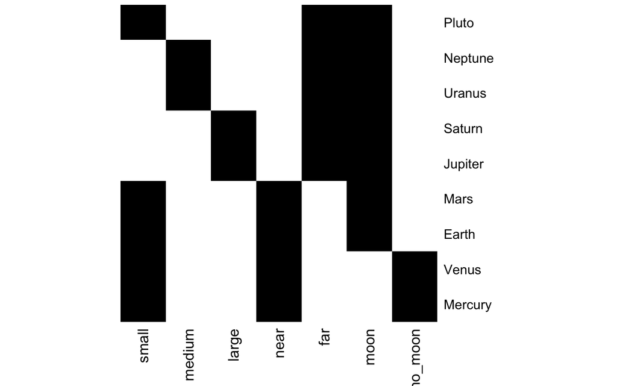

```r
fc_planets$plot()
```

> `fc_planets` can be saved or loaded in a file

```r
fc_planets$save(filename = "./fc_planets.rds")
fcnew <- FormalContext$new("./fc_planets.rds")
fcnew
```

```
## FormalContext with 9 objects and 7 attributes.
##          small  medium  large  near  far  moon  no_moon
##  Mercury   1       0      0      1    0     0      1
##    Venus   1       0      0      1    0     0      1
##    Earth   1       0      0      1    0     1      0
##     Mars   1       0      0      1    0     1      0
##  Jupiter   0       0      1      0    1     1      0
##   Saturn   0       0      1      0    1     1      0
##   Uranus   0       1      0      0    1     1      0
##  Neptune   0       1      0      0    1     1      0
##    Pluto   1       0      0      0    1     1      0
```

## 3.2 Basic methods

### 3.2.1 Derivation operators

**🪄Exercise:** Computing the intent of a set of objects –> *Mars, Earth*:

1. … define a set of objects named `set_objetcs` using `Set$new` (of objects in this case)
2. … store in this variable the attributes for which you want to compute the extent (*Mars* and *Earth* ) - in the crisp case with values *1*
3. … compute the intent via `fc_planets$intent`

```r
set_objetcs <- Set$new(fc_planets$objects)
set_objetcs$assign(Mars = 1, Earth = 1)
fc_planets$intent(set_objetcs)
```

```
## {small, near, moon}
```

**🪄Exercise:** Computing the extent of a set of attributes –> *medium* and *far* :

- … define a set of objects named `set_attributes` using `Set$new` (of attributes in this case)
- … store this variable the attributes for which you want to compute the extent (*medium* and *far* ) - in the crisp case with values *1*
- … compute the extent via `fc_planets$extent`

```r
set_attributes <- Set$new(fc_planets$attributes)
set_attributes$assign(medium = 1, far = 1)
fc_planets$extent(set_attributes)
```

```
## {Uranus, Neptune}
```

> 👁️‍🗨️ This pair of mappings is a Galois connection.

> > 👁️‍🗨️ The composition of intent and extent is the closure of a set of attributes.

### 3.2.2 Closures

**🪄** **Exercise:** Computing the closure of the set of attributes –> *medium*:

- defining a set of objects named `set_attributes1` using `Set$new` (of attributes in this case)
- storing this variable the attributes for which you want to compute the extent (*medium* )
- computing the extent via `fc_planets$closure`

```r
# Compute the closure of S
set_attributes1 <- Set$new(fc_planets$attributes)
set_attributes1$assign(medium = 1)
MyClosure <- fc_planets$closure(set_attributes1)
MyClosure
```

```
## {medium, far, moon}
```

This means that all planets which have the attributes *medium* have *far* and *moon* in common.

# 4 Concept lattice

## 4.1 Concepts

**Definition:** A **formal concept** is a pair $(A,B)$ such that $A \subseteq G$, $B \subseteq M$, $A' = B$ and $B' = A$. Consequently, $A$ and $B$ are closed sets of objects and attributes, respectively.

> 👁️‍🗨️ $\big(\{Jupiter, Saturn\},\{large, far, moon\}\big)$ is a concept. It is a maximal cluster.

> Note: concepts for your .tex documents:

```r
fc_planets$concepts$to_latex()
```

## 4.2 Computing concepts

- `$find_concepts()`

**🪄** **Exercise:** Computing all the concepts from formal context of planets:

- computing the extent via `fc_planets$find_concepts()`
- the concepts remain stored in the variable `fc_planets`
- concepts are accessible from $`concepts()`
- individual concepts can be accessed by their indexes
- concept lattice can be plotted

```r
fc_planets$find_concepts()
fc_planets$concepts
```

```
## A set of 12 concepts:
## 1: ({Mercury, Venus, Earth, Mars, Jupiter, Saturn, Uranus, Neptune, Pluto}, {})
## 2: ({Earth, Mars, Jupiter, Saturn, Uranus, Neptune, Pluto}, {moon})
## 3: ({Jupiter, Saturn, Uranus, Neptune, Pluto}, {far, moon})
## 4: ({Jupiter, Saturn}, {large, far, moon})
## 5: ({Uranus, Neptune}, {medium, far, moon})
## 6: ({Mercury, Venus, Earth, Mars, Pluto}, {small})
## 7: ({Earth, Mars, Pluto}, {small, moon})
## 8: ({Pluto}, {small, far, moon})
## 9: ({Mercury, Venus, Earth, Mars}, {small, near})
## 10: ({Mercury, Venus}, {small, near, no_moon})
## 11: ({Earth, Mars}, {small, near, moon})
## 12: ({}, {small, medium, large, near, far, moon, no_moon})
```

```r
head(fc_planets$concepts)
```

```
## A set of 6 concepts:
## 1: ({Mercury, Venus, Earth, Mars, Jupiter, Saturn, Uranus, Neptune, Pluto}, {})
## 2: ({Earth, Mars, Jupiter, Saturn, Uranus, Neptune, Pluto}, {moon})
## 3: ({Jupiter, Saturn, Uranus, Neptune, Pluto}, {far, moon})
## 4: ({Jupiter, Saturn}, {large, far, moon})
## 5: ({Uranus, Neptune}, {medium, far, moon})
## 6: ({Mercury, Venus, Earth, Mars, Pluto}, {small})
```

```r
firstconcept <- fc_planets$concepts[1]
firstconcept
```

```
## A set of 1 concepts:
## 1: ({Mercury, Venus, Earth, Mars, Jupiter, Saturn, Uranus, Neptune, Pluto}, {})
```

```r
fc_planets$concepts[3:4]
```

```
## A set of 2 concepts:
## 1: ({Jupiter, Saturn, Uranus, Neptune, Pluto}, {far, moon})
## 2: ({Jupiter, Saturn}, {large, far, moon})
```

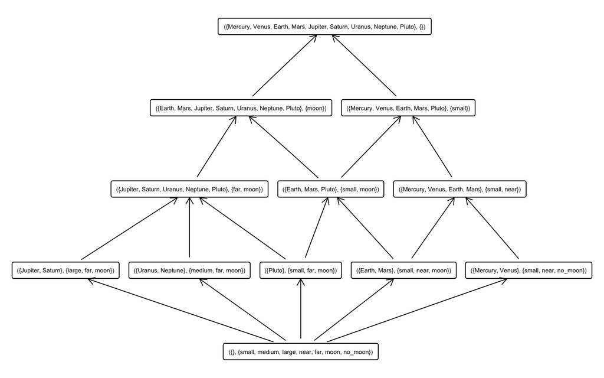

```r
fc_planets$concepts$plot()
```

- `$is_closed`

```r
set_attributes2 <-  Set$new(attributes = fc_planets$attributes)
set_attributes2$assign(moon = 1, large = 1, far= 1)
print("Given the set of attributes:")
```

```
## [1] "Given the set of attributes:"
```

```r
set_attributes2
```

```
## {large, far, moon}
```

```r
print("Is it closed?")
```

```
## [1] "Is it closed?"
```

```r
fc_planets$is_closed(set_attributes2)
```

```
## [1] TRUE
```

```r
set_attributes3 <-  Set$new(attributes = fc_planets$attributes)
set_attributes3$assign(small = 1, far = 1)
print("Given the set of attributes:")
```

```
## [1] "Given the set of attributes:"
```

```r
set_attributes3
```

```
## {small, far}
```

```r
print("Is it closed?")
```

```
## [1] "Is it closed?"
```

```r
fc_planets$is_closed(set_attributes3)
```

```
## [1] FALSE
```

- `$is_concept`

```r
set_objetcs1 <- Set$new(fc_planets$objects)
set_objetcs1$assign(attributes = c('Mercury', 'Venus','Earth', 'Mars'), values=1)
set_attributes1 <- Set$new(fc_planets$attributes)
set_attributes1$assign(attributes = c('small', 'near'), values=1)
Concepto1 <- Concept$new(extent = set_objetcs1,intent = set_attributes1)

fc_planets$is_concept(Concepto1)
```

```
## [1] TRUE
```

```r
set_objetcs1 <- Set$new(fc_planets$objects)
set_objetcs1$assign(attributes = c('Jupiter', 'Saturno'), values=1)
myintent <- fc_planets$intent(set_objetcs1)
myintent
```

```
## {large, far, moon}
```

```r
("And the extent of this one is:")
```

```
## [1] "And the extent of this one is:"
```

```r
myextent <- fc_planets$extent(myintent)
myextent
```

```
## {Jupiter, Saturn}
```

# 5 Implications

## 5.1 Finding implications

> 👁️‍🗨️ `find_implications()`: the function to extract the canonical basis of implications and the concept lattice using the NextClosure algorithm

> … store a `ConceptLattice` and an `ImplicationSet` objects internally in the `FormalContext` object

> … for binary and fuzzy formal contexts

```r
fc_planets$find_implications()
```

## 5.2 Manipulating implications

The computed implications are:

```r
fc_planets$implications
```

```
## Implication set with 10 implications.
## Rule 1: {no_moon} -> {small, near}
## Rule 2: {far} -> {moon}
## Rule 3: {near} -> {small}
## Rule 4: {large} -> {far, moon}
## Rule 5: {medium} -> {far, moon}
## Rule 6: {medium, large, far, moon} -> {small, near, no_moon}
## Rule 7: {small, near, moon, no_moon} -> {medium, large, far}
## Rule 8: {small, near, far, moon} -> {medium, large, no_moon}
## Rule 9: {small, large, far, moon} -> {medium, near, no_moon}
## Rule 10: {small, medium, far, moon} -> {large, near, no_moon}
```

Implications can be read by sub-setting (the same that in R language for vector, etc.):

```r
fc_planets$implications[3]
```

```
## Implication set with 1 implications.
## Rule 1: {near} -> {small}
```

```r
fc_planets$implications[1:4]
```

```
## Implication set with 4 implications.
## Rule 1: {no_moon} -> {small, near}
## Rule 2: {far} -> {moon}
## Rule 3: {near} -> {small}
## Rule 4: {large} -> {far, moon}
```

```r
fc_planets$implications[c(1:4,3)]
```

```
## Implication set with 5 implications.
## Rule 1: {no_moon} -> {small, near}
## Rule 2: {far} -> {moon}
## Rule 3: {near} -> {small}
## Rule 4: {large} -> {far, moon}
## Rule 5: {near} -> {small}
```

Cardinality and size are computed using functions:

1. … the number of implications is computed using `fc_planets$implications$cardinality`
2. … the number of attributes for each implication is computed using `fc_planets$implications$size`

```r
fc_planets$implications$cardinality()
```

```
## [1] 10
```

```r
sizes <- fc_planets$implications$size()
sizes
```

```
##       LHS RHS
##  [1,]   1   2
##  [2,]   1   1
##  [3,]   1   1
##  [4,]   1   2
##  [5,]   1   2
##  [6,]   4   3
##  [7,]   4   3
##  [8,]   4   3
##  [9,]   4   3
## [10,]   4   3
```

```r
colMeans(sizes)
```

```
## LHS RHS
## 2.5 2.3
```

> > **Help**: … for your .tex documents:

```r
fc_planets$implications$to_latex()
```

```
## \begin{longtable*}{rrcl}
## 1: &\ensuremath{\left\{\mathrm{no\_moon}\right\}}&\ensuremath{\Rightarrow}&\ensuremath{\left\{\mathrm{small},\, \mathrm{near}\right\}}\\
## 2: &\ensuremath{\left\{\mathrm{far}\right\}}&\ensuremath{\Rightarrow}&\ensuremath{\left\{\mathrm{moon}\right\}}\\
## 3: &\ensuremath{\left\{\mathrm{near}\right\}}&\ensuremath{\Rightarrow}&\ensuremath{\left\{\mathrm{small}\right\}}\\
## 4: &\ensuremath{\left\{\mathrm{large}\right\}}&\ensuremath{\Rightarrow}&\ensuremath{\left\{\mathrm{far},\, \mathrm{moon}\right\}}\\
## 5: &\ensuremath{\left\{\mathrm{medium}\right\}}&\ensuremath{\Rightarrow}&\ensuremath{\left\{\mathrm{far},\, \mathrm{moon}\right\}}\\
## 6: &\ensuremath{\left\{\mathrm{medium},\, \mathrm{large},\, \mathrm{far},\, \mathrm{moon}\right\}}&\ensuremath{\Rightarrow}&\ensuremath{\left\{\mathrm{small},\, \mathrm{near},\, \mathrm{no\_moon}\right\}}\\
## 7: &\ensuremath{\left\{\mathrm{small},\, \mathrm{near},\, \mathrm{moon},\, \mathrm{no\_moon}\right\}}&\ensuremath{\Rightarrow}&\ensuremath{\left\{\mathrm{medium},\, \mathrm{large},\, \mathrm{far}\right\}}\\
## 8: &\ensuremath{\left\{\mathrm{small},\, \mathrm{near},\, \mathrm{far},\, \mathrm{moon}\right\}}&\ensuremath{\Rightarrow}&\ensuremath{\left\{\mathrm{medium},\, \mathrm{large},\, \mathrm{no\_moon}\right\}}\\
## 9: &\ensuremath{\left\{\mathrm{small},\, \mathrm{large},\, \mathrm{far},\, \mathrm{moon}\right\}}&\ensuremath{\Rightarrow}&\ensuremath{\left\{\mathrm{medium},\, \mathrm{near},\, \mathrm{no\_moon}\right\}}\\
## 10: &\ensuremath{\left\{\mathrm{small},\, \mathrm{medium},\, \mathrm{far},\, \mathrm{moon}\right\}}&\ensuremath{\Rightarrow}&\ensuremath{\left\{\mathrm{large},\, \mathrm{near},\, \mathrm{no\_moon}\right\}}\\
## \end{longtable*}
```

## 5.3 Redudancy Removal

> 👁️‍🗨 Simplification Logic is used to remove redundancy

> > in a **logic style**

> > … applying the rules to the formulas (the implications)

```r
sizes <- fc_planets$implications$size()
colMeans(sizes)
```

```
## LHS RHS
## 2.5 2.3
```

```r
fc_planets$implications$apply_rules(rules = c("composition",
                                      "generalization",
                                      "simplification"),

                            parallelize = FALSE)
```

```
## Processing batch
```

```
## --> Composition: from 10 to 10.
```

```
## --> Generalization: from 10 to 10.
```

```
## --> Simplification: from 10 to 10.
```

```r
sizes <- fc_planets$implications$size()
colMeans(sizes)
```

```
## LHS RHS
## 1.5 2.3
```

```r
fc_planets$implications
```

```
## Implication set with 10 implications.
## Rule 1: {no_moon} -> {small, near}
## Rule 2: {far} -> {moon}
## Rule 3: {near} -> {small}
## Rule 4: {large} -> {far, moon}
## Rule 5: {medium} -> {far, moon}
## Rule 6: {medium, large} -> {small, near, no_moon}
## Rule 7: {moon, no_moon} -> {medium, large, far}
## Rule 8: {near, far} -> {medium, large, no_moon}
## Rule 9: {small, large} -> {medium, near, no_moon}
## Rule 10: {small, medium} -> {large, near, no_moon}
```

```r
equivalencesRegistry$get_entry_names()
```

```
## [1] "Composition"          "Generalization"       "Reduction"
## [4] "Simplification"       "Right Simplification" "Reorder"
```

```r
equivalencesRegistry$get_entry("simplification")
```

```
##      method Simplification
##         fun <<function>>
## description A -> B and C -> D with A, B disjoint, and A subset of C,
##             equivalent to A -> B, C-B -> D-B
```

[Adding new rules to manipulate implications](https://neuroimaginador.github.io/fcaR/articles/extending_equivalence.html)

## 5.4 Validity of implications

> > 👁️‍🗨 … an `ImplicationSet` holds in a `FormalContext` by using the `%holds_in%` operator

```r
imp1 <- fc_planets$implications[1]
imp1 %holds_in% fc_planets
```

```
## [1] TRUE
```

# 6 Basic exercises

1. Compute the intent of `Earth` and `Earth,Mars, Mercury` (use the argument attributes in the class Set).

```
## {Mercury, Earth, Mars}
```

```
## Given the set of objects:
```

```
## {Earth}
```

```
## The intent is:
```

```
## {small, near, moon}
```

```
## Given the set of objects:
```

```
## {Mercury, Earth, Mars}
```

```
## {small, near}
```

2. Compute the extent of `large` and `far,large` (use the argument attributes in the class Set) and save the result in a variable `e1, e2`.

```
## Given the set of objects:
```

```
## {large}
```

```
## The extent is:
```

```
## {Jupiter, Saturn}
```

```
## Given the set of objects:
```

```
## {large, far}
```

```
## {Jupiter, Saturn}
```

2. Compute the intent of variables `e1` and also of `e2`.

```
## {large, far, moon}
```

```
## {large, far, moon}
```

3. With the information from the above questions tell me a concept. Check with any command of fcaR package.
4. Compute the closure of `no_moon`

```
## {small, near, no_moon}
```

```
## ({Earth, Mars, Jupiter, Saturn, Uranus, Neptune, Pluto}, {moon})
```

5. Compute all the concepts and plot them. How many are there? Show the fist and the last (use subsetting).

```
## A set of 2 concepts:
## 1: ({Mercury, Venus, Earth, Mars, Jupiter, Saturn, Uranus, Neptune, Pluto}, {})
## 2: ({}, {small, medium, large, near, far, moon, no_moon})
```

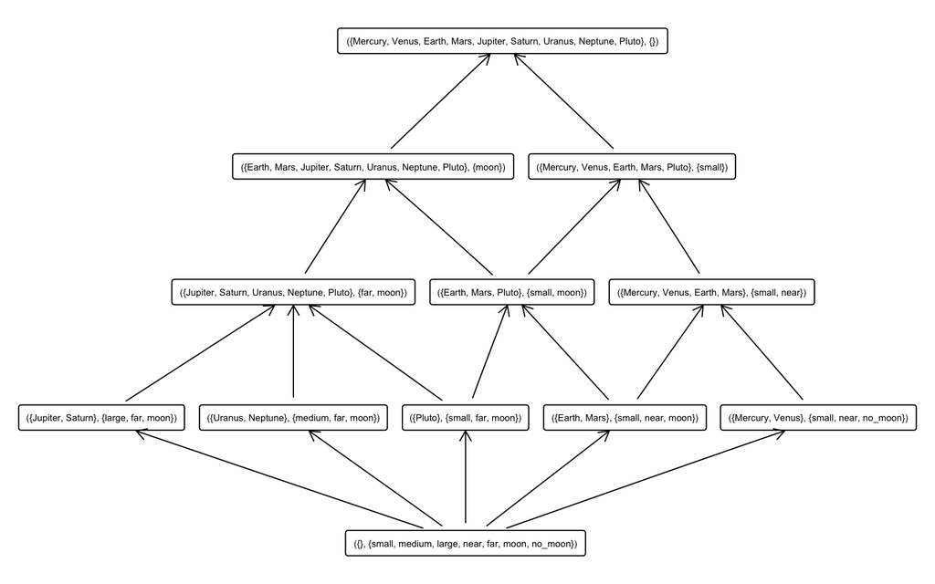

6. Compute the major concept (in lattice) that has moon. The same with no_moon. Locate both in the lattice to understand the meaning.

```
## ({Earth, Mars, Jupiter, Saturn, Uranus, Neptune, Pluto}, {moon})
```

```
## ({Mercury, Venus}, {small, near, no_moon})
```

7. Compute the minor concept (in lattice) that has Pluto The same with Earth. Locate both in the lattice to understand the meaning.

```
## ({Pluto}, {small, far, moon})
```

```
## ({Earth, Mars}, {small, near, moon})
```

# 7 Advanced things

## 7.1 Sublattices

- `$sublattice()`
- to just work with a sublattice of the complete lattice

**🪄** **Exercise:** Computing a sublattice of those concepts with support greater than the threshold

- filtering the concepts (via `support` for instance or selecting some of them for index)
- concepts are accessible from `$sublattice()`

  ```r
  # Compute index of interesting concepts - using support
  idx <- which(fc_planets$concepts$support() > 0.5)
  # Build the sublattice
  sublattice <- fc_planets$concepts$sublattice(idx)
  sublattice
  ```

  ```
  ## A set of 6 concepts:
  ## 1: ({Mercury, Venus, Earth, Mars, Jupiter, Saturn, Uranus, Neptune, Pluto}, {})
  ## 2: ({Earth, Mars, Jupiter, Saturn, Uranus, Neptune, Pluto}, {moon})
  ## 3: ({Jupiter, Saturn, Uranus, Neptune, Pluto}, {far, moon})
  ## 4: ({Mercury, Venus, Earth, Mars, Pluto}, {small})
  ## 5: ({Earth, Mars, Pluto}, {small, moon})
  ## 6: ({Pluto}, {small, far, moon})
  ```

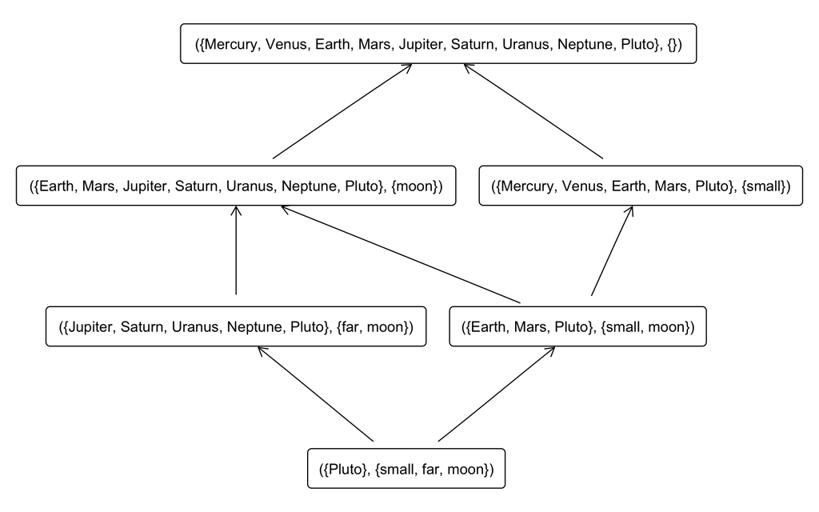

  ```r
  sublattice$plot()
  ```

  ```r
  # Compute index of interesting concepts - using indexes
  idx <- c(8,9,10) # concepts 8, 9 , 10
  # Build the sublattice
  sublattice <- fc_planets$concepts$sublattice(idx)
  sublattice
  ```

  ```
  ## A set of 5 concepts:
  ## 1: ({Mercury, Venus, Earth, Mars, Pluto}, {small})
  ## 2: ({Pluto}, {small, far, moon})
  ## 3: ({Mercury, Venus, Earth, Mars}, {small, near})
  ## 4: ({Mercury, Venus}, {small, near, no_moon})
  ## 5: ({}, {small, medium, large, near, far, moon, no_moon})
  ```

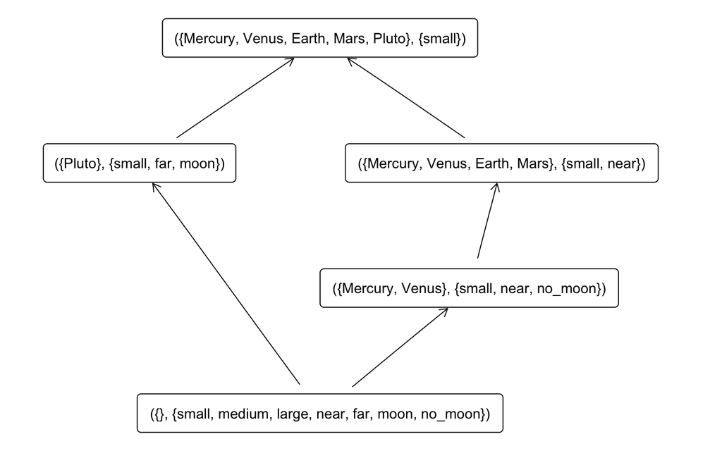

  ```r
  sublattice$plot()
  ```

## 7.2 Concept support

The support of a concept $\langle A, B\rangle$ (A is the extent of the concept and B is the intent) is the cardinality (relative) of the extent - number of objects of the extent.
$$supp(\langle A, B\rangle)=\frac{A}{G}$$

- `$support()`

```r
fc_planets$concepts$support()
```

```
##  [1] 1.0000000 0.7777778 0.5555556 0.2222222 0.2222222 0.5555556 0.3333333
##  [8] 0.1111111 0.4444444 0.2222222 0.2222222 0.0000000
```

> 👁️‍🗨️ The support of itemsets and concepts is used to mine all the knowledge in the dataset: Algorithm Titanic - computing iceberg concept lattices.

## 7.3 Subconcepts, superconcepts, infimum and supremum

Given a concept, we can compute all its subconcepts and all its superconcepts.

**🪄 Exercise:** Find all the subconcepts and superconcepts of the concept number 5 in the list of concepts.

```r
C <- fc_planets$concepts[5]
C
```

```
## A set of 1 concepts:
## 1: ({Uranus, Neptune}, {medium, far, moon})
```

```r
# Its subconcepts:
fc_planets$concepts$subconcepts(C)
```

```
## A set of 2 concepts:
## 1: ({Uranus, Neptune}, {medium, far, moon})
## 2: ({}, {small, medium, large, near, far, moon, no_moon})
```

```r
# And its superconcepts:
fc_planets$concepts$superconcepts(C)
```

```
## A set of 4 concepts:
## 1: ({Mercury, Venus, Earth, Mars, Jupiter, Saturn, Uranus, Neptune, Pluto}, {})
## 2: ({Earth, Mars, Jupiter, Saturn, Uranus, Neptune, Pluto}, {moon})
## 3: ({Jupiter, Saturn, Uranus, Neptune, Pluto}, {far, moon})
## 4: ({Uranus, Neptune}, {medium, far, moon})
```

The same, for supremum and infimum of a set of concetps.

**🪄Exercise:** Find the supremum and the infimum of the concepts 5,6,7.

```r
# A list of concepts
C <- fc_planets$concepts[5:7]
C
```

```
## A set of 3 concepts:
## 1: ({Uranus, Neptune}, {medium, far, moon})
## 2: ({Mercury, Venus, Earth, Mars, Pluto}, {small})
## 3: ({Earth, Mars, Pluto}, {small, moon})
```

```r
# Supremum of the concepts in C
fc_planets$concepts$supremum(C)
```

```
## ({Mercury, Venus, Earth, Mars, Jupiter, Saturn, Uranus, Neptune, Pluto}, {})
```

```r
# Infimum of the concepts in C
fc_planets$concepts$infimum(C)
```

```
## ({}, {small, medium, large, near, far, moon, no_moon})
```

### 7.3.1 Join- and meet- irreducible elements

The irreducible elements with respect to join (supremum) and meet (infimum) can be computed for a given concept lattice:

```r
fc_planets$concepts$join_irreducibles()
```

```
## A set of 5 concepts:
## 1: ({Jupiter, Saturn}, {large, far, moon})
## 2: ({Uranus, Neptune}, {medium, far, moon})
## 3: ({Pluto}, {small, far, moon})
## 4: ({Mercury, Venus}, {small, near, no_moon})
## 5: ({Earth, Mars}, {small, near, moon})
```

```r
fc_planets$concepts$meet_irreducibles()
```

```
## A set of 7 concepts:
## 1: ({Earth, Mars, Jupiter, Saturn, Uranus, Neptune, Pluto}, {moon})
## 2: ({Jupiter, Saturn, Uranus, Neptune, Pluto}, {far, moon})
## 3: ({Jupiter, Saturn}, {large, far, moon})
## 4: ({Uranus, Neptune}, {medium, far, moon})
## 5: ({Mercury, Venus, Earth, Mars, Pluto}, {small})
## 6: ({Mercury, Venus, Earth, Mars}, {small, near})
## 7: ({Mercury, Venus}, {small, near, no_moon})
```

## 7.4 Clarification, reduction

> 👁️‍🗨️ to reduce the context, removing redundancies, while retaining all the knowledge

> `clarify()`, which removes duplicated attributes and objects (columns and rows in the original matrix)

> `reduce()`, which uses closures to remove dependent attributes, but only on binary formal contexts
- … we do a copy of the formal context (`$clone`)
- … do not modify the original –> `fc_planetscopy`

```r
fc_planetscopy <- fc_planets$clone()
fc_planetscopy$clarify(TRUE)
```

```
## FormalContext with 5 objects and 7 attributes.
##                    small  medium  large  near  far  moon  no_moon
##              Pluto   X                          X     X
##   [Mercury, Venus]   X                     X                 X
##      [Earth, Mars]   X                     X          X
##  [Jupiter, Saturn]                  X           X     X
##  [Uranus, Neptune]           X                  X     X
```

```r
fc_planetscopy$reduce(TRUE)
```

```
## FormalContext with 5 objects and 7 attributes.
##                    small  medium  large  near  far  moon  no_moon
##              Pluto   X                          X     X
##   [Mercury, Venus]   X                     X                 X
##      [Earth, Mars]   X                     X          X
##  [Jupiter, Saturn]                  X           X     X
##  [Uranus, Neptune]           X                  X     X
```

> 👁️‍🗨️ Note that merged attributes or objects are stored in the new formal context by using squared brackets to unify them, e.g. `[Mercury, Venus]`

## 7.5 Standard Context

> 👁️‍🗨️ the *standard context* $(J, M, \leq)$, where $J$ is the set of join-irreducible concepts and $M$ are the meet-irreducible ones

> `standardize()`

> > Note: objects are now named J1, J2… and attributes are M1, M2…, from join and meet
- … we do a copy of the formal context (`$clone`)
- … do not modify the original –> `fc_planetscopy`

```r
fc_planetscopy <- fc_planets$clone()
fc_planetscopy$standardize()
```

```
## FormalContext with 5 objects and 7 attributes.
##     M1  M2  M3  M4  M5  M6  M7
##  J1  X   X   X
##  J2  X   X       X
##  J3  X   X           X
##  J4                  X   X   X
##  J5  X               X   X
```

## 7.6 Entailment of implications

> > 👁️‍🗨 … Set1 `%entails%` Set2 - Set2 can be derived (logical consequence) of Set1

```r
imps <- fc_planets$find_implications()
imps2 <- imps$clone()
imps2$apply_rules(c("simp", "rsimp"))
```

```
## Processing batch
```

```
## --> Simplification: from 10 to 10.
```

```
## --> Right Simplification: from 10 to 10.
```

```r
imps %entails% imps2
```

```
##      [,1] [,2] [,3] [,4] [,5] [,6] [,7] [,8] [,9] [,10]
## [1,] TRUE TRUE TRUE TRUE TRUE TRUE TRUE TRUE TRUE  TRUE
```

```r
imps2 %entails% imps
```

```
##      [,1] [,2] [,3] [,4] [,5] [,6] [,7] [,8] [,9] [,10]
## [1,] TRUE TRUE TRUE TRUE TRUE TRUE TRUE TRUE TRUE  TRUE
```

## 7.7 Equivalence of implications

> 👁️‍🗨 … Set1 `%~%` Set2 - Are Set1 and Set2 equivalents?

```r
imps %~% imps2
```

```
## [1] TRUE
```

```r
imps %~% imps2[1:3]
```

```
## [1] FALSE
```

# 8 Advanced exercises

8. Compute the meet irreducible elements in the lattice.

```
## A set of 7 concepts:
## 1: ({Earth, Mars, Jupiter, Saturn, Uranus, Neptune, Pluto}, {moon})
## 2: ({Jupiter, Saturn, Uranus, Neptune, Pluto}, {far, moon})
## 3: ({Jupiter, Saturn}, {large, far, moon})
## 4: ({Uranus, Neptune}, {medium, far, moon})
## 5: ({Mercury, Venus, Earth, Mars, Pluto}, {small})
## 6: ({Mercury, Venus, Earth, Mars}, {small, near})
## 7: ({Mercury, Venus}, {small, near, no_moon})
```

9. Compute the sublattice of the concept in the irreducible elements

```
## A set of 12 concepts:
## 1: ({Mercury, Venus, Earth, Mars, Jupiter, Saturn, Uranus, Neptune, Pluto}, {})
## 2: ({Earth, Mars, Jupiter, Saturn, Uranus, Neptune, Pluto}, {moon})
## 3: ({Jupiter, Saturn, Uranus, Neptune, Pluto}, {far, moon})
## 4: ({Jupiter, Saturn}, {large, far, moon})
## 5: ({Uranus, Neptune}, {medium, far, moon})
## 6: ({Mercury, Venus, Earth, Mars, Pluto}, {small})
## 7: ({Earth, Mars, Pluto}, {small, moon})
## 8: ({Pluto}, {small, far, moon})
## 9: ({Mercury, Venus, Earth, Mars}, {small, near})
## 10: ({Mercury, Venus}, {small, near, no_moon})
## 11: ({Earth, Mars}, {small, near, moon})
## 12: ({}, {small, medium, large, near, far, moon, no_moon})
```

10. Compute the sublattice of the concept in the irreducible elements removing the first element in the list of irreducible elements. Plot this sublattice.

```
## A set of 9 concepts:
## 1: ({Mercury, Venus, Earth, Mars, Jupiter, Saturn, Uranus, Neptune, Pluto}, {})
## 2: ({Jupiter, Saturn, Uranus, Neptune, Pluto}, {far, moon})
## 3: ({Jupiter, Saturn}, {large, far, moon})
## 4: ({Uranus, Neptune}, {medium, far, moon})
## 5: ({Mercury, Venus, Earth, Mars, Pluto}, {small})
## 6: ({Pluto}, {small, far, moon})
## 7: ({Mercury, Venus, Earth, Mars}, {small, near})
## 8: ({Mercury, Venus}, {small, near, no_moon})
## 9: ({}, {small, medium, large, near, far, moon, no_moon})
```

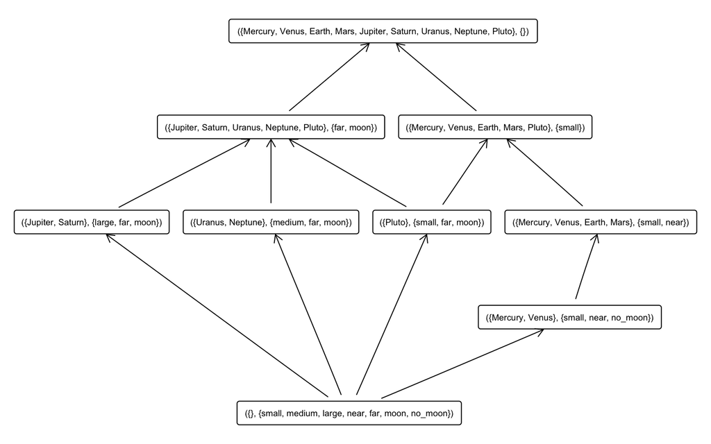